# Chrononormativity CCES 2020 Analysis

# IRT Models

```
##           Dffclt   Dscrmn
## UIL310 1.4801822 3.124124
## UIL311 1.1798857 2.967194
## UIL312 1.1668468 2.537627
## UIL313 1.2436085 2.996590
## UIL314 1.3154922 3.701549
## UIL315 1.1774919 3.217481
## UIL316 1.1161151 3.957006
## UIL317 1.1582238 3.562973
## UIL318 1.4487723 3.246014
## UIL319 1.3853966 3.649291
## UIL320 1.3124810 4.295815
## UIL321 1.1718728 3.104274
## UIL322 1.0525933 2.094986
## UIL323 1.1712534 1.950083
## UIL324 0.9834272 1.841498
## UIL325 0.8818830 2.330502
## UIL326 1.2031503 3.534410
```

```
##
## Item-Fit Statistics and P-values
##
## Call:
## ltm(formula = norm_sum ~ z1, IRT.param = T)
##
## Alternative: Items do not fit the model
## Ability Categories: 10
##
##            X^2 Pr(>X^2)
## UIL310  0.0000        1
## UIL311  2.1774   0.9751
## UIL312  0.4417   0.9999
## UIL313  5.3071   0.7243
## UIL314  0.9114   0.9987
## UIL315  1.5975    0.991
## UIL316  0.3245        1
## UIL317  0.0000        1
## UIL318  0.0000        1
## UIL319  1.9065   0.9837
## UIL320  0.1495        1
## UIL321  0.0049        1
## UIL322 23.5461   0.0027
## UIL323  0.2053        1
## UIL324  0.0000        1
## UIL325  3.8880   0.8671
## UIL326  0.3038        1
```

The difficulty (b) measure determines the underlying trait of Chrononormativity. The easiest way to think of these numbers are as z-scores. The set of items are roughly one standard deviation away from the mean underlying trait of Chrononormativity.

The discrimination (a) measure determines how accurate the item is at assessing how far above and below people the difficulty parameter. Cutoffs between 1 to 4 are usually good here. Items are discriminating well.

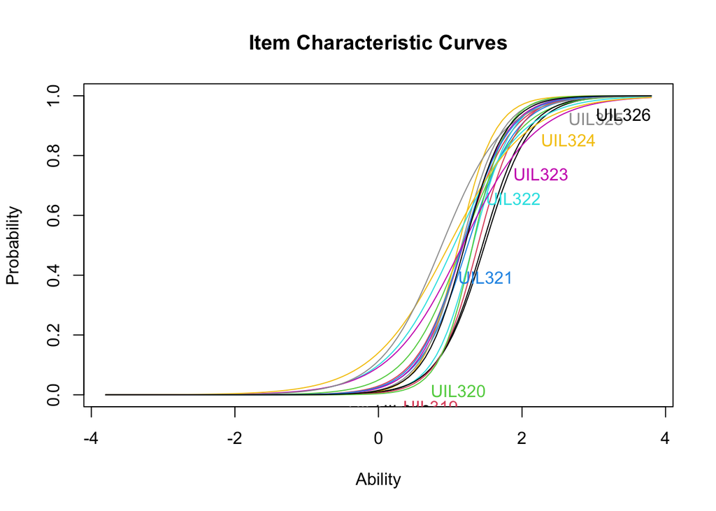

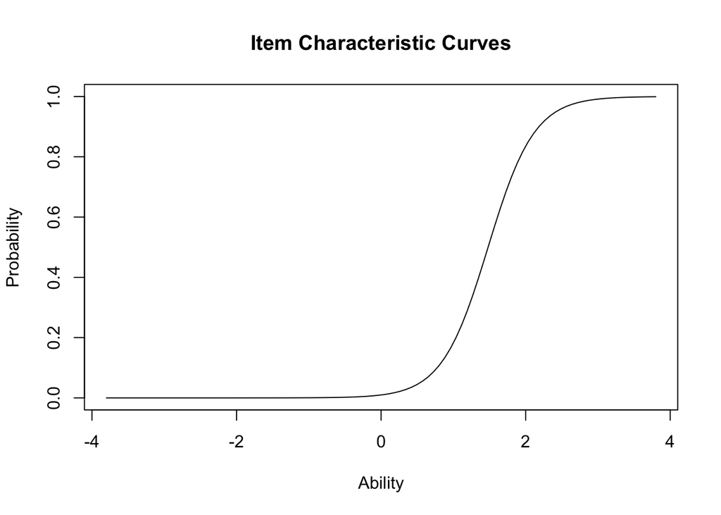

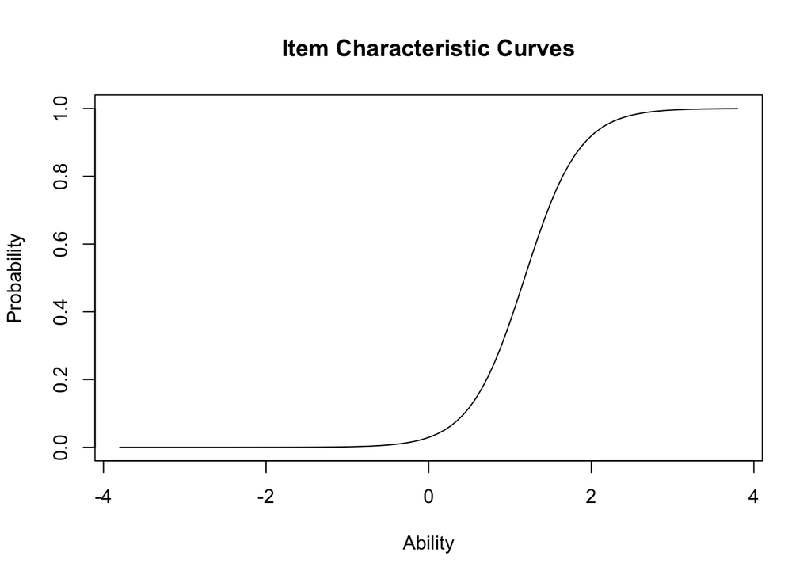

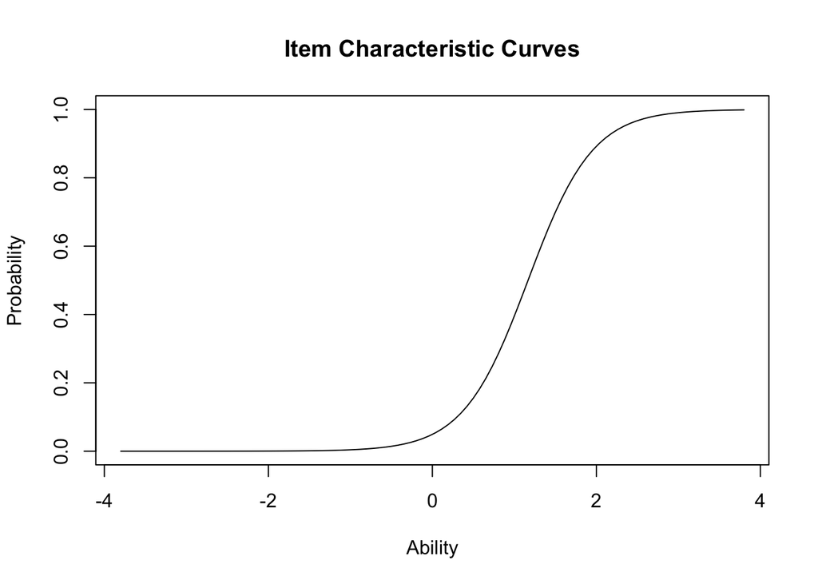

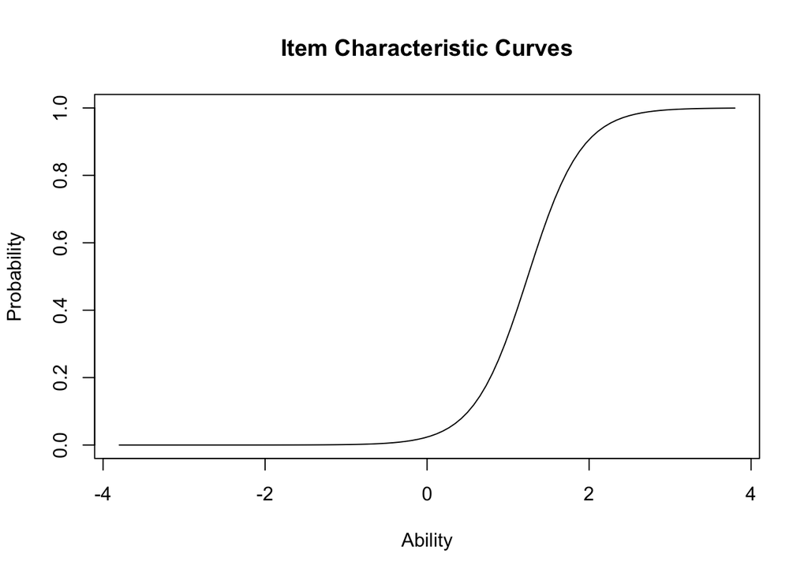

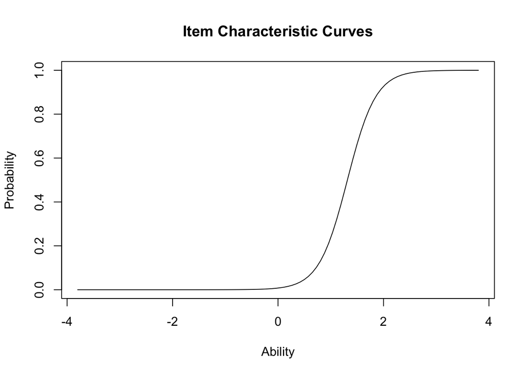

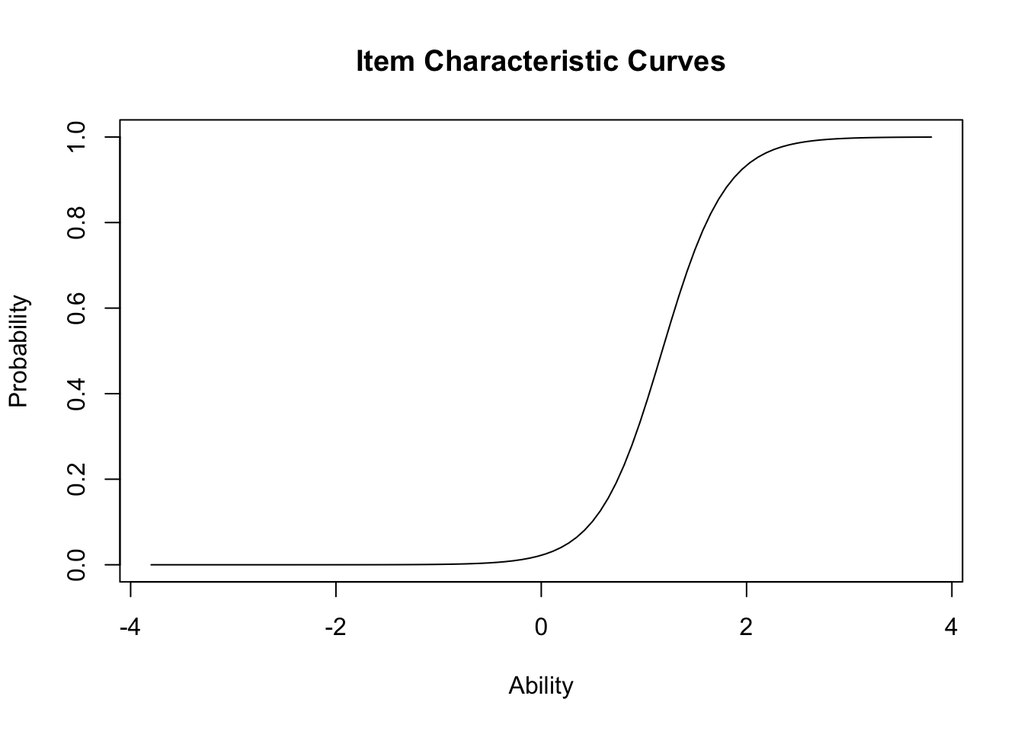

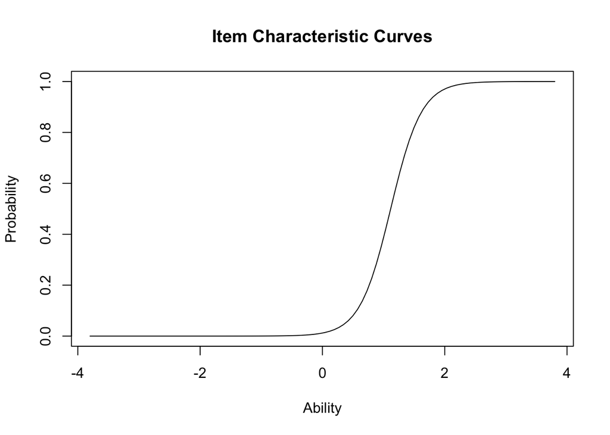

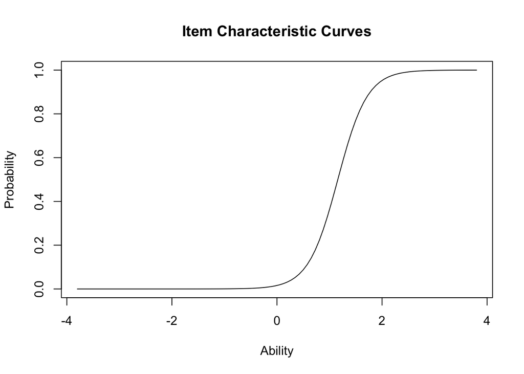